# Assignment 12: Bootstrap Likelihood Ratio Test (BLRT)

Josie Gallop

Due: 04-21-2026

## **Assignment Objectives**

- Enhance understanding the procedure of Bootstrap hypothesis testing.
- Implement the procedures for detecting overfitting/underfitting issues in practical applications using bootstrap likelihood ratio test.

## **Policies of Using AI Tools**

**Policy on AI Tool Use**: Please adhere to the AI tool policy specified in the course syllabus. The direct copying of AI-generated content is strictly prohibited. All submitted work must reflect your own understanding; where external tools are consulted, content must be thoroughly rephrased and synthesized in your own words.

**Code Inclusion Requirement**: Any code included in your essay must be properly commented to explain the purpose and/or expected output of key code lines. Submitting AI-generated code without meaningful, student-added comments will not be accepted.

## Testing Overfitting/Underfitting

In Machine Learning and Statistics, overfitting occurs when a model is too complex and learns noise, leading to poor performance on new data, while underfitting happens when a model is too simple to capture important patterns, resulting in high errors overall; both issues are explained by the Bias–Variance Tradeoff and can cause unreliable predictions in real-world applications.

The probability density function (PDF) of the Weibull distribution is:

$$f(t; \lambda, \beta) = \frac{\beta}{\lambda} \left( \frac{t}{\lambda}
\right)^{\beta-1} \exp\left[ -\left( \frac{t}{\lambda} \right)^\beta
\right], \quad t \ge 0$$
where $\lambda > 0$ is the scale parameter (characteristic life) and $\beta > 0$ is the shape parameter.

When $\beta = 1$, the Weibull PDF simplifies to the exponential PDF:

$$f(t; \lambda) = \frac{1}{\lambda} \exp\left( -\frac{t}{\lambda} \right)$$
with constant hazard rate $h(t) = 1/\lambda$.

**This assignment focuses on performing a hypothesis test for the shape parameter ($\beta$) of the Weibull distribution within a reliability mode**

$$\begin{align}
H_0&: \beta = 1 \quad \text{(Exponential model, simpler)} \\
H_1&: \beta \neq 1 \quad \text{(Weibull model, more complex)}
\end{align}$$

## Steps of the BLRT

- Fit models under $H_0$ and $H_1$} to the original data, compute $\Lambda_{\text{obs}}$.
- Generate bootstrap samples under $H_0$}:
  - Estimate parameters under $H_0$ from the original data.
  - Generate $B$ datasets by sampling from the model under $H_0$ (parametric bootstrap) or by resampling residuals/cases (nonparametric bootstrap; parametric is common for BLRT).
- For each bootstrap sample $b = 1,\dots,B$:
  - Fit $H_0$ and $H_1$ models.
  - Compute $\Lambda_b = -2[\ell_{0,b} - \ell_{1,b}]$.
- Approximate p-value:

$$p = \frac{1}{B} \sum_{b=1}^B I(\Lambda_b \ge \Lambda_{\text{obs}})$$
(Often a small adjustment is made for stability: $(1 + \#\{\Lambda_b \ge \Lambda_{\text{obs}}\})/(B+1)$).

## **Question: Reliability Application**

A wind energy company monitors the reliability of gearboxes in 75 identical wind turbines located in a coastal wind farm. The gearbox is a critical component; its failure often leads to costly downtime and repairs. Previous studies suggest that the hazard rate (failure risk) may increase over time due to mechanical wear (fatigue, pitting, bearing degradation). Engineers want to test whether the failure time distribution follows an exponential model (constant hazard, random failures) or a Weibull model with shape parameter $k>1$ (increasing hazard, indicative of aging/degradation). The failure times (in months) are:

```
   5.2,  7.8,  9.1, 11.3, 12.5, 13.0, 14.2, 15.1, 15.9, 16.7, 17.2, 17.8, 18.4, 18.9,
  19.3, 19.7, 20.2, 20.6, 21.0, 21.5, 21.9, 22.3, 22.7, 23.1, 23.5, 23.9, 24.3, 24.7,
  25.1, 25.5, 25.9, 26.3, 26.7, 27.1, 27.5, 27.9, 28.3, 28.7, 29.1, 29.5, 29.9, 30.3,
  30.7, 31.1, 31.5, 31.9, 32.3, 32.7, 33.1, 33.5, 33.9, 34.3, 34.7, 35.1, 35.5, 35.9,
  36.3, 36.7, 37.1, 37.5, 37.9, 38.3, 38.7, 39.1, 39.5, 39.9, 40.3, 40.7, 41.1, 41.5,
  41.9, 42.3, 42.7, 43.1, 43.5
```

This assignment focuses on hypothesis $H_0: \beta = 1$ (exponential) against $H_1: \beta \neq 1$ (Weibull). This framework detects overfitting (fitting a Weibull when exponential is true) and underfitting (fitting exponential when Weibull with $\beta \neq 1$ is true).

a). Find the MLE of the Weibull parameters $\lambda$ (scale) and $\beta$ (shape), denoted by $\hat{\lambda}$ and $\hat{\beta}$, respectively, using the `optim()` procedure. [*Hint: You should provide explicit expressions for the log-likelihood and gradient functions of the Weibull distribution parameters.*]

First, I will begin by storing the data within a data set. These observations represent failure times (in months) of the gearboxes in 75 wind turbines. These failure times were measured, because the failure of these gearboxes is a critical and costly issue when they must be repaired. This data set will be called “times”.

```r
times <- c(5.2,  7.8,  9.1, 11.3, 12.5, 13.0, 14.2, 15.1, 15.9, 16.7, 17.2, 17.8, 18.4, 18.9, 19.3, 19.7, 20.2, 20.6, 21.0, 21.5, 21.9, 22.3, 22.7, 23.1, 23.5, 23.9, 24.3, 24.7, 25.1, 25.5, 25.9, 26.3, 26.7, 27.1, 27.5, 27.9, 28.3, 28.7, 29.1, 29.5, 29.9, 30.3, 30.7, 31.1, 31.5, 31.9, 32.3, 32.7, 33.1, 33.5, 33.9, 34.3, 34.7, 35.1, 35.5, 35.9, 36.3, 36.7, 37.1, 37.5, 37.9, 38.3, 38.7, 39.1, 39.5, 39.9, 40.3, 40.7, 41.1, 41.5, 41.9, 42.3, 42.7, 43.1, 43.5)

n <- length(times)
```

I will now find the MLE of the Weibull parameters $\lambda$ and $\beta$, denoted by $\hat{\lambda}$ and $\hat{\beta}$. I will use the optim() procedure.

I know that the PDF of the Weibull distribution is as follows: $f(t;\lambda,\beta)=\frac{\beta}{\lambda}\left(\frac{t}{\lambda}\right)^{\beta-1}\exp\left[-\left(\frac{t}{\lambda}\right)^\beta\right], \quad t \ge 0$

So, the log-likelihood function for this Weibull distribution would be: $\ell(\lambda,\beta)=n\log\beta - n\beta\log\lambda + (\beta-1)\sum_{i=1}^n \log t_i - \sum_{i=1}^n \left(\frac{t_i}{\lambda}\right)^\beta$

The gradient functions for the Weibull parameters, $\lambda$ and $\beta$, are as given below.

First, for $\lambda$: $\frac{\partial \ell}{\partial \lambda} = -\frac{n\beta}{\lambda} + \frac{\beta}{\lambda} \sum_{i=1}^n \left(\frac{t_i}{\lambda}\right)^\beta$

Then, for $\beta$: $\frac{\partial \ell}{\partial \beta} = \frac{n}{\beta} - n\log\lambda + \sum_{i=1}^n \log t_i - \sum_{i=1}^n \left(\frac{t_i}{\lambda}\right)^\beta \log\left(\frac{t_i}{\lambda}\right)$

I will use these gradients as well as the overall log likelihood function for the Weibull distribution in my R function.

```r
weibull_ll <- function(par){
  lambda <- par[1]
  beta <- par[2]

  if(lambda <= 0 || beta <= 0) return(Inf)

  ll <- n*log(beta) - n*beta*log(lambda) +
        (beta-1)*sum(log(times)) -
        sum((times/lambda)^beta)

  return(-ll)
}

# Optimization
fit_weibull <- optim(c(mean(times), 1), weibull_ll, method="L-BFGS-B",
                     lower=c(1e-6,1e-6))

lambda_hat <- fit_weibull$par[1]
beta_hat <- fit_weibull$par[2]

lambda_hat
```

```
[1] 31.4182
```

```r
beta_hat
```

```
[1] 3.370781
```

It turns out that $\hat{\lambda}$ = 31.42 and $\hat{\beta}$ = 3.37.

b). Find the MLE of the exponential parameter $\lambda$ (scale), denoted by $\hat{\lambda}$, using any procedure. [*Hint: You should provide explicit expressions for the log-likelihood and gradient functions of the exponential distribution parameters.*]

Next, I will find the MLE of the exponential parameter $\lambda$, denoted by $\hat{\lambda}$. I know that the PDF for an exponential distribution is: $f(t;\lambda)=\frac{1}{\lambda} e^{-t/\lambda}, \quad t \ge 0$

So, the log likelihood function for this exponential distribution is: $\ell(\lambda) = -n \log \lambda - \frac{1}{\lambda} \sum_{i=1}^n t_i$

The MLE for $\hat{\lambda}$ is: $\hat{\lambda} = \bar{t} = \frac{1}{n} \sum_{i=1}^n t_i$.

I will use this information to find the $\hat{\lambda}$ parameter for the given data. I will begin by manually calculating this parameter using the gradients and log likehood function, similar to what was done in the previous part. Then, I will verify this by calculating the mean of the data, as I know that the MLE parameter for an exponential distribution must equal the mean of the observations.

```r
loglik_exp <- function(lambda){
  if(lambda <= 0) return(Inf)
  ll <- -n*log(lambda) - sum(times)/lambda
  return(-ll)
}

grad_exp <- function(lambda){
    grad <- -(-n/lambda + sum(times)/lambda^2)
    return(grad)
}

fit_exp <- optim(par = 100, fn = loglik_exp, gr = grad_exp,
                 method = "BFGS",  hessian = TRUE)

lambda_exp_hat <- fit_exp$par
lambda_exp_hat
```

```
[1] 28.18262
```

It turns out that $\hat{\lambda}$ = 28.18. Therefore, the MLE of the Exponential parameter is $\hat{\lambda}$ = 28.18. I will verify this result by finding the mean of the times data set. This should give the same result because I know that $\hat{\lambda} = \bar{t}$ for an exponential distribution.

```r
lambda_exp_hat1 <- mean(times)
lambda_exp_hat1
```

```
[1] 28.18533
```

I get that $\bar{t}$ = 28.19. This matches up with my result from the manual way of finding the MLE for the exponential parameter $\hat{\lambda}$, just with some slight rounding differences to the hundredths decimal place. Therefore, my results and the R function are correct because they match up with one another.

c). Use a) and b) to perform the regular likelihood ratio $\chi^2$ test for $\beta = 1$ and report the p-value.

I will perform the likelihood ratio $\chi^2$ test for $\beta = 1$. For this test, the test statistic is $\Lambda = -2\left(\ell_{H_0} - \ell_{H_1}\right)$. It will be tested whether it is true that $\beta = 1$ or if $\beta$ significantly differs from 1. If it is true that $\beta$ significantly differs from 1, then the more complex Weibull model would be preferred. If it turns that $\beta$ does not differ from 1, then the more simpler Exponential model would be preferred

The hypotheses are as follows:

$H_0: \beta = 1 \quad \text{(Exponential model)}$

$H_1: \beta \neq 1 \quad \text{(Weibull model)}$

Under the null hypothesis, $\Lambda \sim \chi^2_1$. An R function will be created the find the likelihood ratio test statistic, and find its p-value to test whether it is statistically significant. An $\alpha$ = 0.05 significance level will be used.

```r
# Log-likelihood under H0 (Beta = 1)
loglik_exp <- function(lambda){
  -n*log(lambda) - sum(times)/lambda
}

ll_exp <- loglik_exp(lambda_exp_hat)
ll_weibull <- -fit_weibull$value

LR <- -2*(ll_exp - ll_weibull)
p_value_LR <- 1 - pchisq(LR, df=1)

LR
```

```
[1] 100.6144
```

```r
p_value_LR
```

```
[1] 0
```

The likelihood ratio test statistic is $\lambda$ = 100.61, with p-value < .001. In this case, the p-value is less than $\alpha$ = 0.05 so we will reject the null hypothesis and conclude that there is sufficient evidence that $\beta \neq 1$. The Weibull model is preferred over the Exponential model.

d). Use the BLRT algorithm to perform a bootstrap likelihood ratio test and report the bootstrap p-value. Note that you are expected to translate the BLRT algorithm into R code to perform the BLRT. [*Hint: The chi-square distribution should not be used in this part of the analysis.*]

Now, I will use the BLRT algorithm to perform a bootstrap likelihood ratio test. I will find the p-value of this bootstrap test, and compare my findings to those from the previous part. In the previous part, part c, the regular likelihood ratio test resulted in a p-value of p < .001. This lead to the conclusion to reject the null hypothesis, and conclude that the Weibull model is preferred over the exponential model. So, I expect the BLRT algorithm and the bootstrap likelihood ratio test to give a significant p-value, less than the significance level of $\alpha$ = 0.05.

I will write an R function to perform the bootstrap likelihood ratio test using the BLRT algorithm. I will generate 1,000 bootstrap samples under the null hypothesis. This corresponds to the exponential model, so I will use the exponential parameter of $\hat{\lambda}$ = 28.18 from part b for this step. For each bootstrap sample, the exponential model (null hypothesis) will be fit by finding the MLE. Next, the Weibull model (alternative hypothesis) will be fit to find the MLEs. Then, the function will compute the bootstrap likelihood ratio test statistic. The found bootstrap test statistic will be used to find the overall bootstrap p-value. This bootstrap p-value will be printed below, and assessed for its significance.

```r
set.seed(123)

# Generate 1,000 bootstrap samples
B <- 1000
Lambda_boot <- numeric(B)

for(b in 1:B){

  # Generating samples under H0
  times_boot <- rexp(n, rate = 1/lambda_exp_hat)

  # Fitting the Exponential model
  lambda_boot <- mean(times_boot)
  ll0_b <- -n*log(lambda_boot) - sum(times_boot)/lambda_boot

  # Fitting the Weibull model
  weibull_ll_boot <- function(par){
    lambda <- par[1]
    beta <- par[2]
    if(lambda <= 0 || beta <= 0) return(Inf)

    ll <- n*log(beta) - n*beta*log(lambda) +
          (beta-1)*sum(log(times_boot)) -
          sum((times_boot/lambda)^beta)
    return(-ll)
  }

  fit_boot <- optim(c(mean(times_boot),1), weibull_ll_boot,
                    method="L-BFGS-B",
                    lower=c(1e-6,1e-6))

  # Bootstrap likelihood ratio statistic
  ll1_b <- -weibull_ll_boot(fit_boot$par)
  Lambda_boot[b] <- -2*(ll0_b - ll1_b)
}

# Bootstrap p-value
p_value_boot <- (1 + sum(Lambda_boot >= LR)) / (B + 1)
p_value_boot
```

```
[1] 0.000999001
```

The bootstrap likelihood ratio test resulted in a bootstrap p-value of p = 0.001. The bootstrap p-value is less than $\alpha$ = 0.05 so we will reject the null hypothesis and conclude that there is sufficient evidence that $\beta \neq 1$. The Weibull model is preferred over the exponential model. This matches up with the previous findings.

e). Write a summary of the above analyses to address the following:

- Whether the two tests generated the same results.
- Which model is recommended for the data.

Two tests were conducted to determine whether the Weibull model or the Exponential model were a better fit for the failure times data. These two tests conducted were the chi-square likelihood ratio test and the bootstrap likelihood ratio test. These tests assessed the null hypothesis of whether the $\beta$ parameter equals one, against the alternative hypothesis of whether the $\beta$ parameter significantly differed from the value of one. If the null hypothesis would be rejected, this would mean that the Weibull model is the better fit, as the hazard rate over time is not constant, and would need a more complex model to represent it. If the null hypothesis could not be rejected, this would mean that the Exponential model is the better fit, as it assumes a constant hazard rate.

Both the chi-square likelihood ratio test and the bootstrap likelihood ratio test resulted in statistically significant p-values of p < 0.001 and p = 0.001 respectively. At the $\alpha$ = 0.05 significance level, both of these p-values fell beneath this significance threshold, indicating that the null hypothesis should be rejected. Therefore, both tests concluded that there is sufficient evidence that $\beta$ truly differs from one, meaning there is not a constant hazard rate. This means that the Weibull model is the better choice for this specific data.

It was found in part a that $\hat{\beta}$ = 3.37. This means that the $\beta$ parameter for the failure times data is estimated to be 3.37. This suggests an increasing hazard rate. Both tests concluded that the $\beta$ parameter significantly differs from one, and therefore, is non-constant. This positive $\beta$ parameter suggests an increasing hazard rate over time.

Overall, both the chi-square likelihood ratio test and the bootstrap likelihood ratio test found the same conclusion. Both tests concluded that the null hypothesis should be rejected, and the true hazard rate, $\beta$, significantly differs from one. Therefore, the Weibull model is the best choice in this case, as it accounts for a non-constant $\beta$ parameter. The Exponential model assumes a constant hazard rate, and so it would not be the best fit for this specific data. The Weibull model is the best fit, and best represents the failure times data.

A visualization was made to show a comparison of the Weibull and Exponential density curves, along with the histogram of the failure times data. This plot will show how the density curves for each of the two models compare to the overall data. This will show how the fit of the two models compares to one another, which can help further show the better model for this particular data.

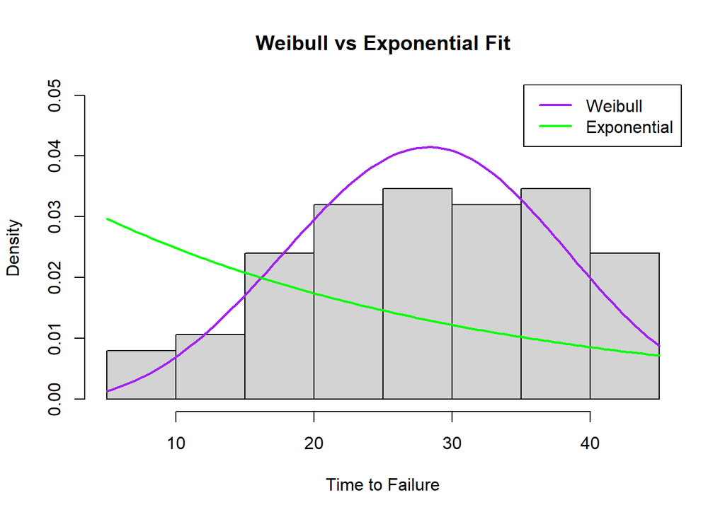

```r
hist(times, probability = TRUE, col = "lightgray", breaks = 10,
     main = "Weibull vs Exponential Fit",
     xlab = "Time to Failure",
     ylim = c(0, max(dweibull(times, shape = beta_hat, scale = lambda_hat),
                    dexp(times, rate = 1/lambda_exp_hat)) * 1.2))

# Weibull curve
curve(dweibull(x, shape = beta_hat, scale = lambda_hat),
      col = "purple", lwd = 2, add = TRUE)

# Exponential curve
curve(dexp(x, rate = 1/lambda_exp_hat),
      col = "green", lwd = 2, add = TRUE)

legend("topright",
       legend = c("Weibull", "Exponential"),
       col = c("purple", "green"), lwd = 2)
```

The plot shows the two density curves for the Weibull model and the Exponential model. It can be seen that the Weibull curve has a much better fit to the failure times data. The Exponential curve does not fit the data well at all, which strengthens the conclusion that it is the Weibull model that should be used instead. This plot further strengthens the conclusion to pick the Weibull model.

Altogether, it is clear that the Weibull model is the best choice for the failure times data. The Weibull model accounts for a non-constant hazard rate. Both the chi-square likelihood test and the bootstrap likelihood test concluded that the data has a non-constant hazard rate. So, it is clear that the more complex model best suits this data by accounting for this non-constant hazard rate. Therefore, the Weibull model is the best choice for this failure times data.